# E-commerce Customer & Sales Insights

Rhys Tutt

22 December 2017

## Setup

For this analysis I’ll be using the tidyquant package (loads many packages from the TidyVerse), plotly (interactive charts), countrycode (to derive iso country codes from country names) and a few other packages I like to use for visualizations - gridExtra, ggthemes & scales.

Also, for the sake of full explanation, I had some issues with the dates being in a US format and so upon importing in Excel they were being formatted to the wrong dates. This requred a bit of manipulation in Excel, which I did by uploading the file as a text data source, changing the formatting of the dates column to text, then stripping the various parts of the date into different columns and combining them using concatenate (fairly quick 10 min process). E.g. formulas like =LEFT(E2,FIND(“/”,E2)-1) & =MID(E2,3,FIND(“/”,E2)).

You can see the old column “OldInvoiceDate” below and the various different date components I pulled from this.

```r
set.seed(123)
dataset <- read.csv("dataset2.csv")
glimpse(dataset)
```

```
## Observations: 541,909
## Variables: 13
## $ InvoiceNo      <fctr> 536365, 536365, 536365, 536365, 536365, 536365...
## $ StockCode      <fctr> 85123A, 71053, 84406B, 84029G, 84029E, 22752, ...
## $ Description    <fctr> WHITE HANGING HEART T-LIGHT HOLDER, WHITE META...
## $ Quantity       <int> 6, 6, 8, 6, 6, 2, 6, 6, 6, 32, 6, 6, 8, 6, 6, 3...
## $ OldInvoiceDate <fctr> 12/01/2010 8:26, 12/01/2010 8:26, 12/01/2010 8...
## $ UnitPrice      <dbl> 2.55, 3.39, 2.75, 3.39, 3.39, 7.65, 4.25, 1.85,...
## $ CustomerID     <int> 17850, 17850, 17850, 17850, 17850, 17850, 17850...
## $ Country        <fctr> United Kingdom, United Kingdom, United Kingdom...
## $ Month          <int> 12, 12, 12, 12, 12, 12, 12, 12, 12, 12, 12, 12,...
## $ Day            <int> 1, 1, 1, 1, 1, 1, 1, 1, 1, 1, 1, 1, 1, 1, 1, 1,...
## $ Year           <int> 2010, 2010, 2010, 2010, 2010, 2010, 2010, 2010,...
## $ InvoiceDate    <fctr> 1/12/2010, 1/12/2010, 1/12/2010, 1/12/2010, 1/...
## $ Period         <fctr> 2010-12, 2010-12, 2010-12, 2010-12, 2010-12, 2...
```

## Data Clean-Up & Preparation

First we look to see if there are any missing values, we can see CustomerID appears to be optional, this is common with e-commerce data as registering an account is not compulsory.

We don’t want to impute any data here, just need to keep it in mind when analysing further, e.g. we wouldn’t place all the importance on counting distinct customers.

```r
head(dataset[!complete.cases(dataset),])
```

```
##      InvoiceNo StockCode                     Description Quantity
## 623     536414     22139                                       56
## 1444    536544     21773 DECORATIVE ROSE BATHROOM BOTTLE        1
## 1445    536544     21774 DECORATIVE CATS BATHROOM BOTTLE        2
## 1446    536544     21786              POLKADOT RAIN HAT         4
## 1447    536544     21787           RAIN PONCHO RETROSPOT        2
## 1448    536544     21790              VINTAGE SNAP CARDS        9
##        OldInvoiceDate UnitPrice CustomerID        Country Month Day Year
## 623  12/01/2010 11:52      0.00         NA United Kingdom    12   1 2010
## 1444 12/01/2010 14:32      2.51         NA United Kingdom    12   1 2010
## 1445 12/01/2010 14:32      2.51         NA United Kingdom    12   1 2010
## 1446 12/01/2010 14:32      0.85         NA United Kingdom    12   1 2010
## 1447 12/01/2010 14:32      1.66         NA United Kingdom    12   1 2010
## 1448 12/01/2010 14:32      1.66         NA United Kingdom    12   1 2010
##      InvoiceDate  Period
## 623    1/12/2010 2010-12
## 1444   1/12/2010 2010-12
## 1445   1/12/2010 2010-12
## 1446   1/12/2010 2010-12
## 1447   1/12/2010 2010-12
## 1448   1/12/2010 2010-12
```

Can also see there are some 0 values for quanities and prices. This could be useful to analyse what products are being abandoned and if there are any trends that may be indicative of software errors on the business end or similar. But for the purpose of this analysis I’m going to remove those with a price of 0 or a quantity of 0 items purchased.

```r
dataset <- dataset %>%
  filter(UnitPrice > 0, Quantity > 0 )
```

I intend to perform some analysis by country, there are often different naming conventions so will look at this feature.

```r
summary(dataset$Country)
```

```
##            Australia              Austria              Bahrain
##                 1182                  398                   18
##              Belgium               Brazil               Canada
##                 2031                   32                  151
##      Channel Islands               Cyprus       Czech Republic
##                  748                  614                   25
##              Denmark                 EIRE   European Community
##                  380                 7890                   60
##              Finland               France              Germany
##                  685                 8407                 9040
##               Greece            Hong Kong              Iceland
##                  145                  284                  182
##               Israel                Italy                Japan
##                  295                  758                  321
##              Lebanon            Lithuania                Malta
##                   45                   35                  112
##          Netherlands               Norway               Poland
##                 2359                 1071                  330
##             Portugal                  RSA         Saudi Arabia
##                 1501                   57                    9
##            Singapore                Spain               Sweden
##                  222                 2484                  451
##          Switzerland United Arab Emirates       United Kingdom
##                 1966                   68               485123
##          Unspecified                  USA
##                  446                  179
```

Can see a few issues here - EIRE is an old way of saying Republic of Ireland, Channel Islands is actually a group of two islands which will make it hard to obtain the country code so I will just re-name it to one of them (Jersey), European Community is very non-specific but not much we can do here, RSA is a bit ambiguous so will re-name to Republic of South Africa, and there are some Unspecified values but there’s not much we can do about those.

```r
dataset$Country <- as.character(dataset$Country)

dataset <- dataset %>%
  mutate(Country = replace(Country, Country == "EIRE","Republic of Ireland")) %>%
  mutate(Country = replace(Country, Country == "RSA","Republic of South Africa")) %>%
  mutate(Country = replace(Country, Country == "Channel Islands","Jersey"))

dataset$Country <- as.factor(dataset$Country)

summary(dataset$Country)
```

```
##                Australia                  Austria                  Bahrain
##                     1182                      398                       18
##                  Belgium                   Brazil                   Canada
##                     2031                       32                      151
##                   Cyprus           Czech Republic                  Denmark
##                      614                       25                      380
##       European Community                  Finland                   France
##                       60                      685                     8407
##                  Germany                   Greece                Hong Kong
##                     9040                      145                      284
##                  Iceland                   Israel                    Italy
##                      182                      295                      758
##                    Japan                   Jersey                  Lebanon
##                      321                      748                       45
##                Lithuania                    Malta              Netherlands
##                       35                      112                     2359
##                   Norway                   Poland                 Portugal
##                     1071                      330                     1501
##      Republic of Ireland Republic of South Africa             Saudi Arabia
##                     7890                       57                        9
##                Singapore                    Spain                   Sweden
##                      222                     2484                      451
##              Switzerland     United Arab Emirates           United Kingdom
##                     1966                       68                   485123
##              Unspecified                      USA
##                      446                      179
```

We would probably want to have a word to the software developer team to see if we can have some sort of address validation or an improved country dropdown list implemented to suit our requirements.

## Country Analysis

We’ll summarise the data by Country as this will be interesting to delve into where our customers are coming from.

```r
country <- dataset %>%
  group_by(Country) %>%
  summarise(CountCustomers = n_distinct(CustomerID),
            CountInvoices = n_distinct(InvoiceNo),
            SumPurchases = sum(Quantity * UnitPrice)) %>%
  arrange(desc(CountCustomers)) %>%
  mutate(CountryCode = countrycode(sourcevar = Country, "country.name", "iso3c"))
head(country)
```

```
## # A tibble: 6 x 5
##          Country CountCustomers CountInvoices SumPurchases CountryCode
##           <fctr>          <int>         <int>        <dbl>       <chr>
## 1 United Kingdom           3921         18019   9025222.08         GBR
## 2        Germany             94           457    228867.14         DEU
## 3         France             88           392    209715.11         FRA
## 4          Spain             30            90     61577.11         ESP
## 5        Belgium             25            98     41196.34         BEL
## 6    Switzerland             22            54     57089.90         CHE
```

Using plotly I’ll build an interactive map to visualize these insights.

As we can see, most of the revenue is coming from Europe, which is obviously important to know for a variety of logistical and marketing reasons.

[interactive chart not shown]

One thing I would mention is that depending on the business, we may want to try and expand our market into other countries not only to continue growth but also greater diversify the business risk.

As you can see below, the UK makes up almost 85% of our revenue and if something were to happen in this market, e.g. the introduction of a new competitor or a legislation change outside of our control, this could be catastrophic for our business.

So I suggest it would be prudent to hedge this risk and focus on growing some of our other market shares.

```r
country <- country %>%
  mutate(TotalPurchases = sum(SumPurchases))

select(
  country %>%
  group_by(Country) %>%
  mutate(Freq = formatC(100.0 * (SumPurchases / TotalPurchases), digits = 2, format = "f")) %>%
  arrange(desc(Freq))
  , Country, SumPurchases,Freq)
```

```
## # A tibble: 38 x 3
## # Groups:   Country [38]
##                Country SumPurchases  Freq
##                 <fctr>        <dbl> <chr>
##  1      United Kingdom   9025222.08 84.61
##  2         Netherlands    285446.34  2.68
##  3 Republic of Ireland    283453.96  2.66
##  4             Germany    228867.14  2.15
##  5              France    209715.11  1.97
##  6           Australia    138521.31  1.30
##  7               Spain     61577.11  0.58
##  8         Switzerland     57089.90  0.54
##  9             Belgium     41196.34  0.39
## 10              Sweden     38378.33  0.36
## # ... with 28 more rows
```

## Order Insights

We could group all the items by invoice number and perform some analysis, like clustering. I did this and didn’t include it in this analysis as nothing too interesting was found.

```r
invoices <-
  dataset %>%
  group_by(InvoiceNo, CustomerID, InvoiceDate) %>%
  summarise(NumItems = n_distinct(Description),
            TotalQuantity = sum(Quantity),
            TotalAmount = sum(Quantity * UnitPrice),
            AvgUnitPrice = mean(UnitPrice),
            AvgItemAmount = mean(Quantity * UnitPrice))
```

Instead I’ll just add an aggregated colum summing the quantity and unit price.

```r
orders <-
  dataset %>%
  group_by(InvoiceNo, CustomerID, InvoiceDate, Period, Description, UnitPrice) %>%
  summarise(TotalQuantity = sum(Quantity),
            TotalAmount = sum(Quantity * UnitPrice))

head(orders)
```

```
## # A tibble: 6 x 8
## # Groups:   InvoiceNo, CustomerID, InvoiceDate, Period, Description [6]
##   InvoiceNo CustomerID InvoiceDate  Period
##      <fctr>      <int>      <fctr>  <fctr>
## 1    536365      17850   1/12/2010 2010-12
## 2    536365      17850   1/12/2010 2010-12
## 3    536365      17850   1/12/2010 2010-12
## 4    536365      17850   1/12/2010 2010-12
## 5    536365      17850   1/12/2010 2010-12
## 6    536365      17850   1/12/2010 2010-12
## # ... with 4 more variables: Description <fctr>, UnitPrice <dbl>,
## #   TotalQuantity <int>, TotalAmount <dbl>
```

We can then plot the price and quantity on a chart and can see that as price increases, the quantity bought naturally decreases (as is the case in most environments).

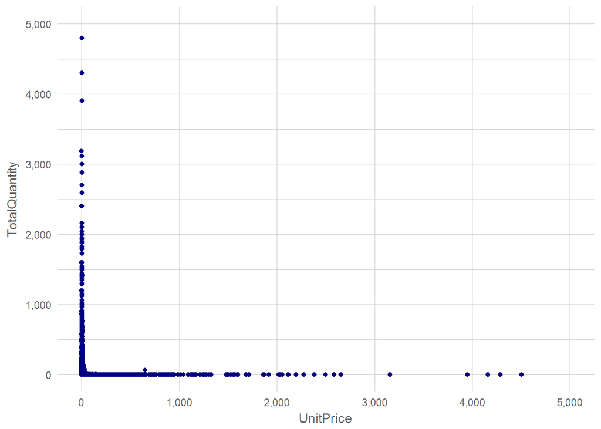

Next we can perform some basic analysis by date.

Then we plot this in a bar chart and use the “scales” package for the formatting of y axis with commas. I like to make sure all the little things are done right as it makes a big difference in aesthetic and interpretability.

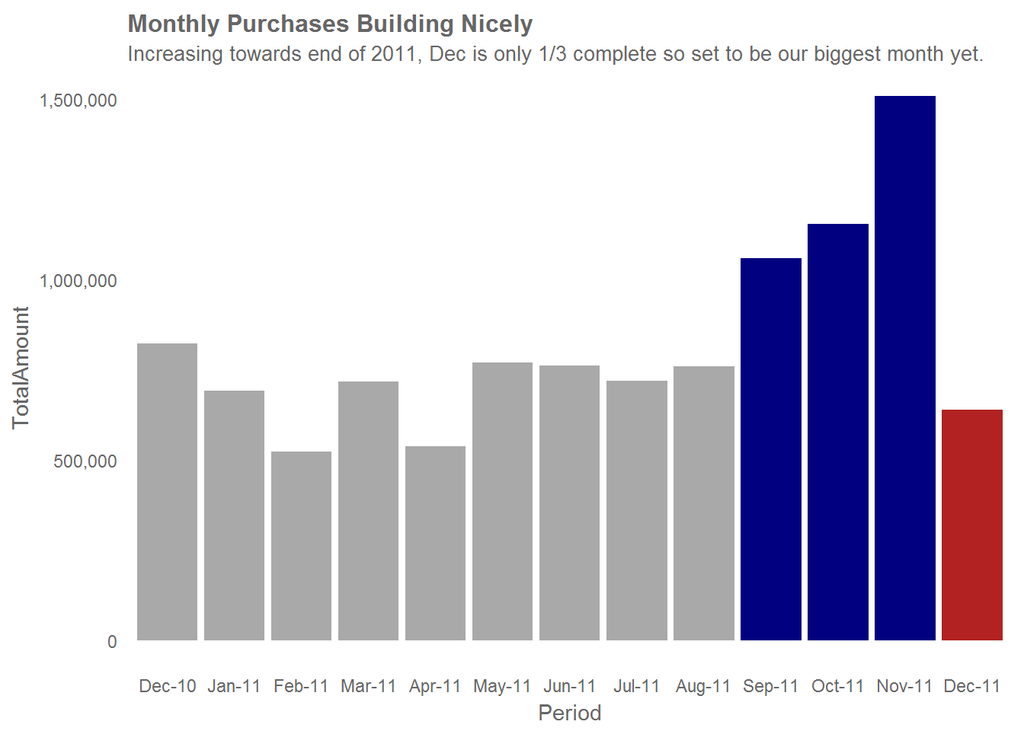

This could then lead into more advanced forecasting but that’s beyond the scope of this insights analysis.

In a real business enviornment, I have previously written SQL queries with while loops and then associated KPI month-to-date infographics in R to track the progress of sales compared to the same time in previous months and ROI benchmarks.

## Customer Insights

By running an un-supervised machine learning algorithm like k-means clustering, we can find patterns or groupings in the data which we weren’t aware of previously. This is especially valuable as rather than looking for pre-determined information, clustering can identify hidden patterns we hadn’t realised before.

Also worth noting, although the following charts are a more polished product, I first explore the variables very quickly using the base plotting system.

First, we’ll group the customers by their CustomerID and perform some aggregations which I’ll use in further plots, then we’ll remove those customers who don’t have a CustomerID.

```r
customers <-
  dataset %>%
  group_by(CustomerID) %>%
  summarise(NumInvoices = n_distinct(InvoiceNo),
            NumItems = n_distinct(Description),
            TotalItemQuantity = sum(Quantity),
            TotalAmount = sum(Quantity * UnitPrice),
            AvgUnitPrice = mean(UnitPrice),
            AvgItemAmount = mean(Quantity * UnitPrice)) %>%
  mutate(AvgInvoiceAmount = TotalAmount / NumInvoices)

customers <- customers[complete.cases(customers),]

glimpse(customers)
```

```
## Observations: 4,338
## Variables: 8
## $ CustomerID        <int> 12346, 12347, 12348, 12349, 12350, 12352, 12...
## $ NumInvoices       <int> 1, 7, 4, 1, 1, 8, 1, 1, 1, 3, 1, 2, 4, 3, 1,...
## $ NumItems          <int> 1, 103, 22, 73, 17, 59, 4, 58, 13, 53, 131, ...
## $ TotalItemQuantity <int> 74215, 2458, 2341, 631, 197, 536, 20, 530, 2...
## $ TotalAmount       <dbl> 77183.60, 4310.00, 1797.24, 1757.55, 334.40,...
## $ AvgUnitPrice      <dbl> 1.040000, 2.644011, 5.764839, 8.289041, 3.84...
## $ AvgItemAmount     <dbl> 77183.60000, 23.68132, 57.97548, 24.07603, 1...
## $ AvgInvoiceAmount  <dbl> 77183.6000, 615.7143, 449.3100, 1757.5500, 3...
```

We’ll use the elbow method to determine the best number of clusters that explain the most variability within the data.

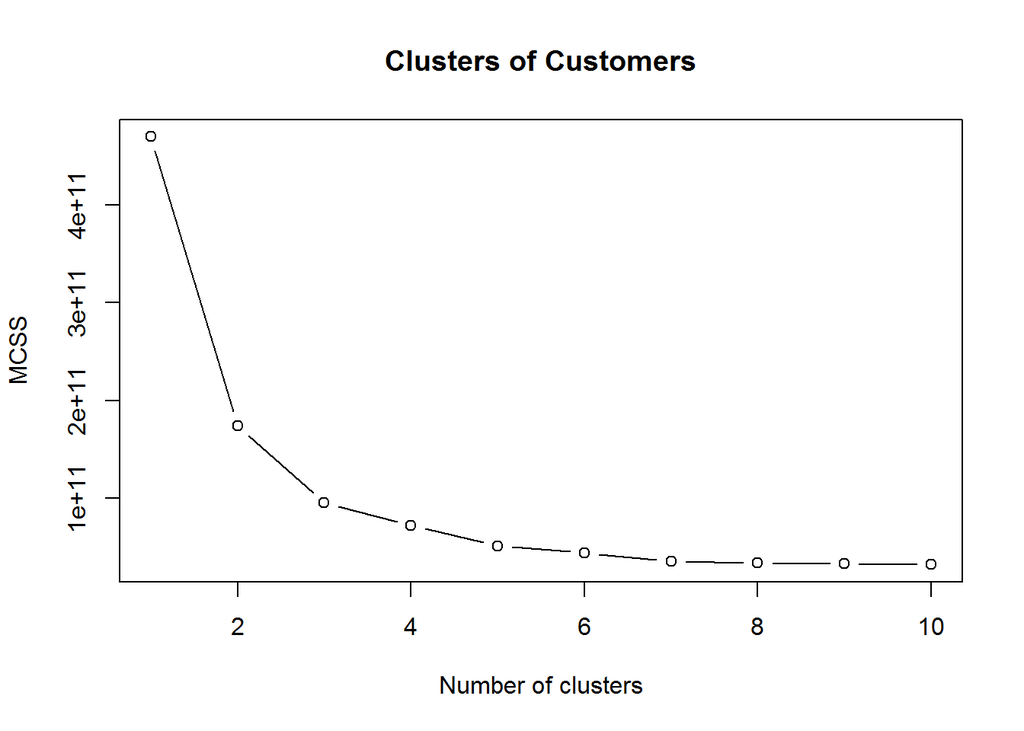

```r
set.seed(123)
wcss <- vector()
for (i in 1:10) wcss[i] <- sum(kmeans(customers[,c(2:7)], i)$withinss)
plot(1:10, wcss, type = 'b', main = paste("Clusters of Customers"), xlab = "Number of clusters", ylab = "MCSS")
```

Then we run the k-means algorithm, specifying we want 4 clusters, a maximum of 300 iterations and 10 random starts.

```r
set.seed(123)
kmeans <- kmeans(customers[,c(2:7)], centers = 4, iter.max = 300, nstart = 10)
table(kmeans$cluster)
```

```
##
##    1    2    3    4
##   98    4   15 4221
```

We’ll add these clusters to the customers table and label them based on their value (these definitions will become apparent): 4 = lower value, 1 = mid value, 3 = higher value, 2 = top value.

This is not to say those of low value are not important to our business, but by segmenting them by total value we can better analyse their differences.

```r
customers <-
  customers %>%
  add_column(Cluster = kmeans$cluster)

customers$Cluster <- factor(customers$Cluster,
                            levels = c(4,1,3,2),
                            labels = c("Low","Medium","High","Top"))
```

If we plot this data we can see a natural segmentation within the data by total item quantity and total amount purchased.

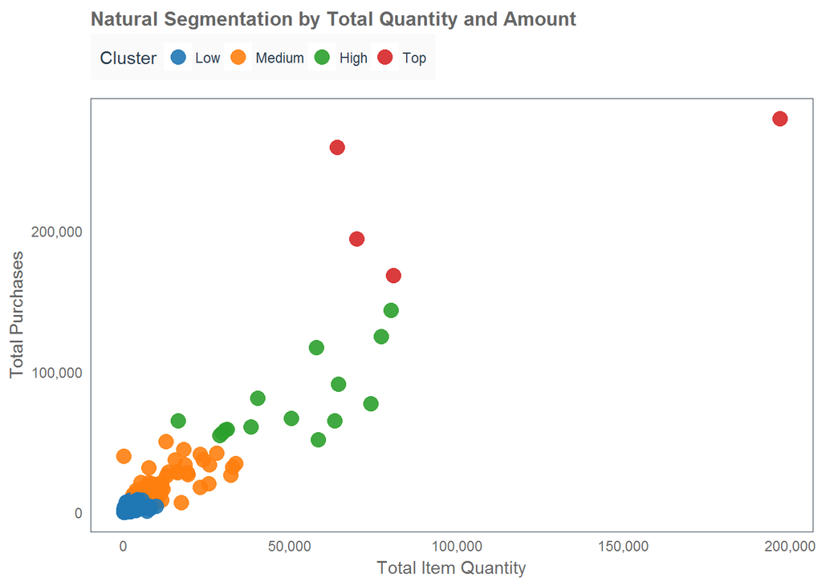

To understand the Clusters better, we can look at the proportions these segments make up of our customer base and total revenue. Often you will see Pareto’s principle where 80% of the profits come from 20% of customers. In our dataset, it is evident that around 3% of our customer base is accounting for around 42% of our total purchases.

Although if we delved even deeper into the actual distinct customers, I’d argue we would probably see Pareto’s principle evident in the data, but we won’t dive that deep in this analysis.

```r
totalrevenue <- sum(customers$TotalAmount)
totalcustomers <- n_distinct(customers$CustomerID)

customerfreq <-
  customers %>%
  group_by(Cluster) %>%
  summarise(CountCustomers = n(),
            TotalPurchases = sum(TotalAmount)) %>%
  mutate(PurchaseFreq = formatC(100 * TotalPurchases / totalrevenue, digits = 2, format = "f"),
         CountFreq = formatC(100 * CountCustomers / totalcustomers, digits = 2, format = "f"))
```

Plotting these relative proportions side-by-side will make my point more evident.

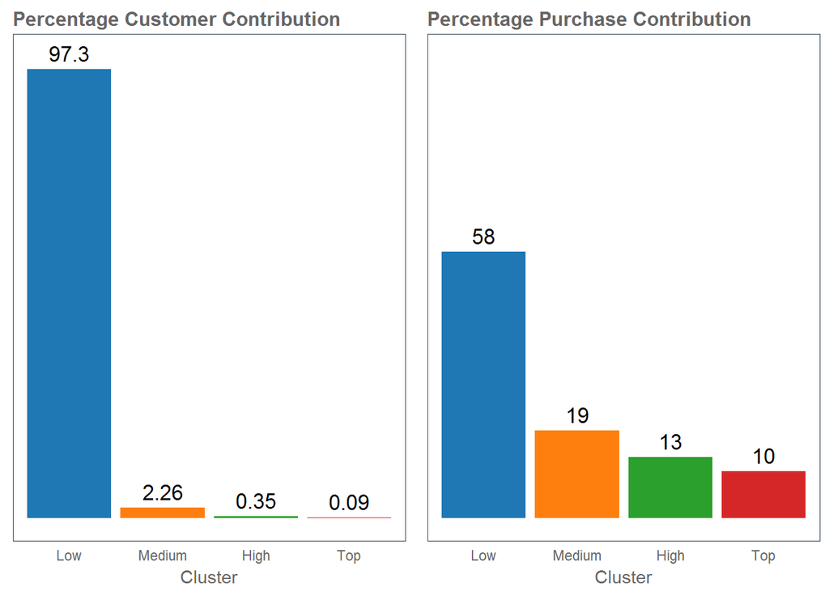

So now that we understand a bit more about our customer base, we would obviously want to gain further insights on the different segments and how best to approach each of them.

First, we can plot the number of invoices each customer has made and the number of items they purchased on each invoice. So we can see that value isn’t necessarily about the sheer number of invoices, but rather the number of items per invoice. We can also extrapolate from this data that our higher value segments are big distributors or wholesale customers.

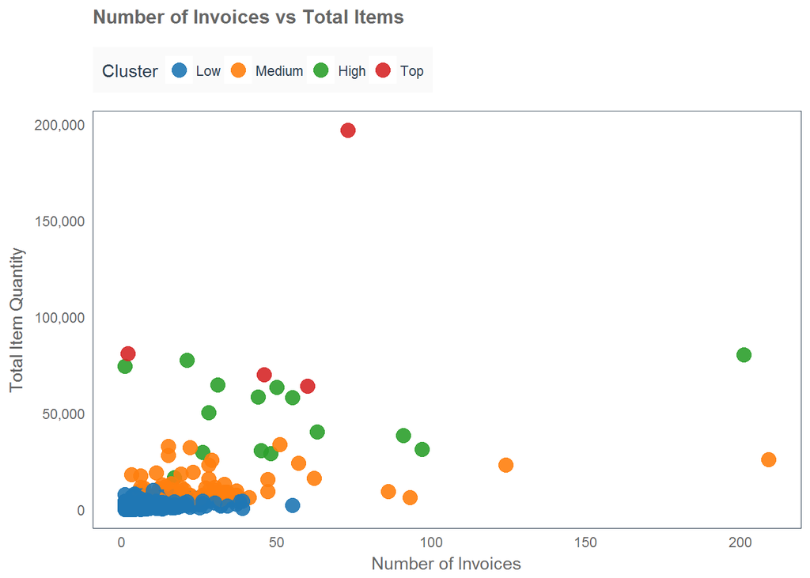

We can also see different trends in the chart below, for example our top customers often order a smaller variety of items in bulk, whereas our lower level customers (probably regular retail customers) usually order a smaller quantity of a wider variety of items.

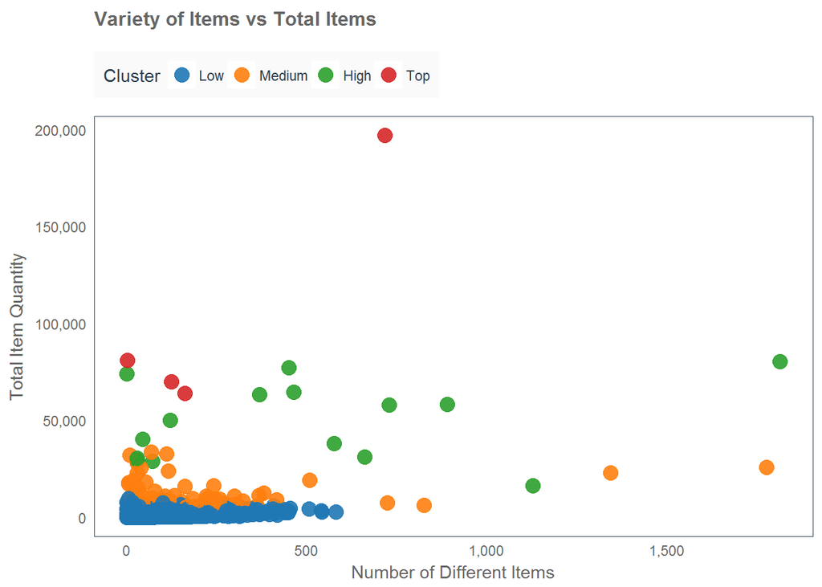

Another interesting observation is that the higher value groups average unit price is lower, so they’re buying large quantities of low priced items.

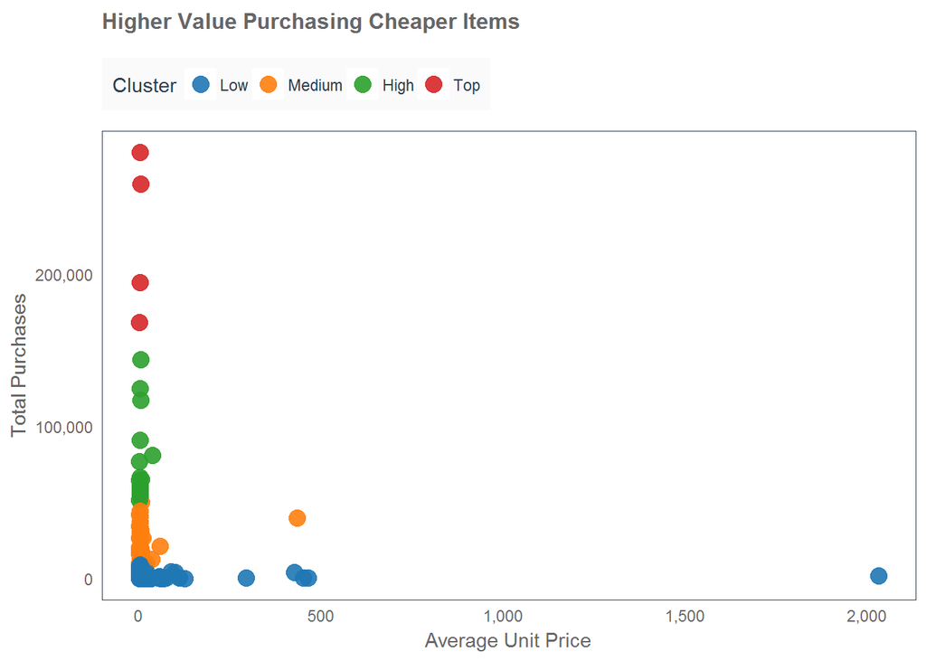

So value is actually being driven largely by the number of items purchased.

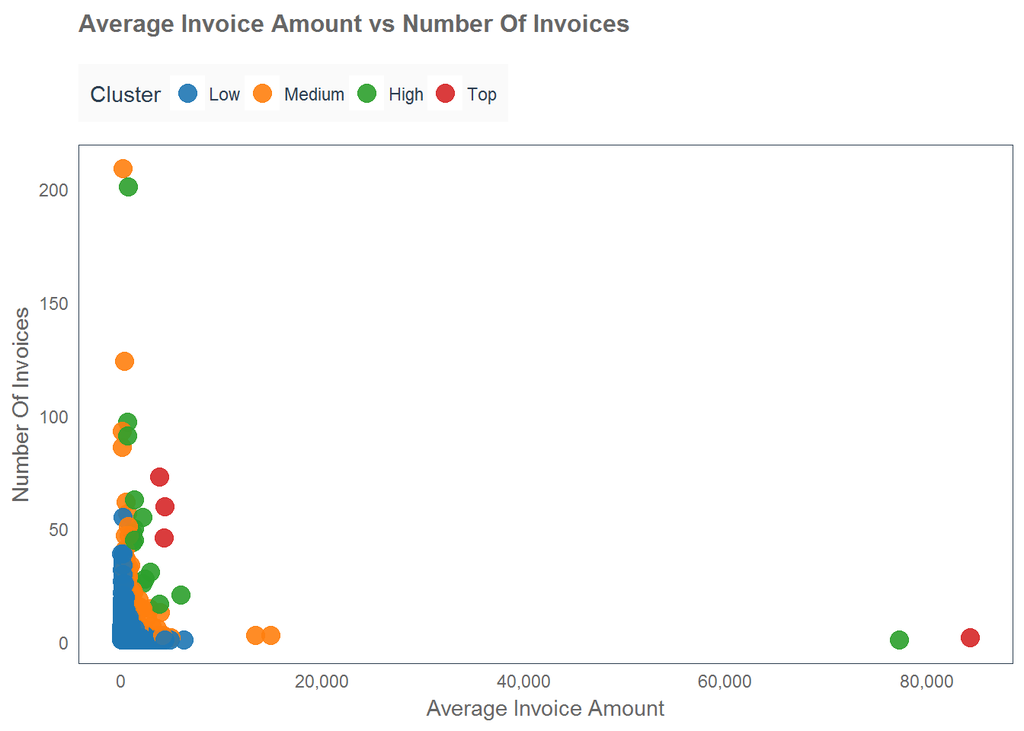

## Conclusion

So we can actually start using this information for various business operations like driving marketing strategy. For example, we could target our higher value segments (wholesalers) with a more specific selection of items and offer bulk discounts; whereas with our lower value segment (regular retail customers) we might offer a wider array of items with percentage discount offers.

With these regular retail customers, there would also be scope to do some collaborative filtering or build a recommendation system to assist us with which specific items to advertise to each customer based on what similar customers have purchased.

These are obviously just a few methods of gaining insights and the next possibilites here are endless, but some common steps I would look at taking next would be trying to assign a customer lifetime value (CLV), performing RFM segmentation based on the recency, frequency, and monetary amount spent, and then performing further clustering.